# Modeling & Results

```python
%matplotlib inline
import numpy as np
import scipy as sp
import matplotlib.pyplot as plt
import pandas as pd
import seaborn as sns
pd.set_option('display.width', 500)
pd.set_option('display.max_columns', 100)
pd.set_option('display.notebook_repr_html', True)
sns.set()
from sklearn.model_selection import train_test_split
from sklearn.linear_model import LogisticRegression
from sklearn.linear_model import LogisticRegressionCV
from sklearn.model_selection import cross_val_score
from sklearn.discriminant_analysis import LinearDiscriminantAnalysis
from sklearn.discriminant_analysis import QuadraticDiscriminantAnalysis
from sklearn.utils import resample
from sklearn.tree import DecisionTreeClassifier
from sklearn.ensemble import BaggingClassifier
from sklearn.ensemble import RandomForestClassifier
from sklearn.ensemble import AdaBoostClassifier
from sklearn.metrics import accuracy_score
from sklearn.model_selection import GridSearchCV
from sklearn.neighbors import KNeighborsClassifier
from sklearn.calibration import CalibratedClassifierCV
from sklearn.svm import LinearSVC
import warnings
warnings.filterwarnings('ignore')
```

### Data Preparation

```python
# load the dataset for match results and team ratings
X = pd.read_csv('worldcup2018/datasets/Scrapes/final_X2.csv', index_col='Unnamed: 0')

# compute a new feature for international prestige difference
X['international_prestige_diff'] = X['home_team_international_prestige'] - X['away_team_international_prestige']
X.head()
```

|  | date | home_team | away_team | home_score | away_score | tournament | city | country | neutral | home_rank | home_rank_pts | away_rank | away_rank_pts | rank_diff | rank_pts_diff | outcome | outcome_num | home_game | away_game | home_OVR | home_ATT | home_MID | home_DEF | home_team_id | home_team_uid | home_team_international_prestige | away_OVR | away_ATT | away_MID | … |
| --- | --- | --- | --- | --- | --- | --- | --- | --- | --- | --- | --- | --- | --- | --- | --- | --- | --- | --- | --- | --- | --- | --- | --- | --- | --- | --- | --- | --- | --- | --- |
| 0 | 2010-05-26 | France | Costa Rica | 2.0 | 1.0 | Friendly | Lens | France | 0.0 | 9.0 | 1044.0 | 40.0 | 710.0 | -31.0 | 334.0 | W | 0.0 | 1.0 | 0.0 | 82.0 | 80.0 | 82.0 | 81.0 | 1335.0 | 1335-11-156279 | 19.0 | 73.0 | 69.0 | 73.0 | … |
| 1 | 2011-02-09 | Venezuela | Costa Rica | 2.0 | 2.0 | Friendly | Puerto la Cruz | Venezuela | 0.0 | 60.0 | 515.0 | 69.0 | 467.0 | -9.0 | 48.0 | D | 1.0 | 1.0 | 0.0 | 71.0 | 74.0 | 69.0 | 70.0 | 111487.0 | 111487-13-157186 | 5.0 | 73.0 | 69.0 | 73.0 | … |
| 2 | 2011-12-22 | Venezuela | Costa Rica | 0.0 | 2.0 | Friendly | Barquisimeto | Venezuela | 0.0 | 39.0 | 661.0 | 65.0 | 495.0 | -26.0 | 166.0 | L | 2.0 | 1.0 | 0.0 | 71.0 | 74.0 | 69.0 | 70.0 | 111487.0 | 111487-13-157186 | 5.0 | 73.0 | 69.0 | 73.0 | … |
| 3 | 2018-03-27 | Tunisia | Costa Rica | 1.0 | 0.0 | Friendly | Nice | France | 1.0 | 23.0 | 920.0 | 26.0 | 872.0 | -3.0 | 48.0 | W | 0.0 | 0.0 | 0.0 | 73.0 | 75.0 | 71.0 | 71.0 | 1391.0 | 1391-09-155725 | 3.0 | 73.0 | 69.0 | 73.0 | … |
| 4 | 2010-06-01 | Switzerland | Costa Rica | 0.0 | 1.0 | Friendly | Sion | Switzerland | 0.0 | 24.0 | 866.0 | 40.0 | 710.0 | -16.0 | 156.0 | L | 2.0 | 1.0 | 0.0 | 76.0 | 74.0 | 72.0 | 73.0 | 1364.0 | 1364-11-156279 | 11.0 | 73.0 | 69.0 | 73.0 | … |

5 rows × 177 columns

```python
# let's find out the distribution of wins, losses and draws in our dataset
class_counts = X.outcome.value_counts()
display(pd.DataFrame(
    {"Number of instances": class_counts,
     "%": class_counts / class_counts.sum()},
    ).rename_axis("Class"))
```

| Class | Number of instances | % |
| --- | --- | --- |
| W | 731 | 0.446004 |
| L | 471 | 0.287370 |
| D | 437 | 0.266626 |

Our dataset is slightly imbalanced: almost 45% of the games are "wins".

```python
# split the data into historical and wc data
historical_data = X[X['date'] <= '2018-06-13']
wc_data = X[X['date'] > '2018-06-13']

# split the historical data into train and test sets
train_data, test_data = train_test_split(historical_data, test_size=.2, stratify=historical_data.outcome_num)
len(train_data), len(test_data), len(wc_data)
```

```
(1260, 315, 64)
```

### Model Building

Let's first build a baseline model. The idea behind it is to include only a few features from our dataset to see how well it performs on the test set. Once we get the baseline model accuracy, we will compare it to an advanced model that includes many other features - most of which are generated using feature engineering.

#### Baseline Model

```python
# define the feature set for our baseline model
predictors = ['ATT_diff', 'MID_diff', 'DEF_diff','rank_pts_diff']

# scale the features
def scale_df(df, means, stds):
    cols_to_scale = means.index
    df = df.copy()
    df[cols_to_scale] = (df[cols_to_scale] - means) / stds
    return df

cols_to_scale = predictors

train_means = train_data[cols_to_scale].mean(axis=0)
train_stds = train_data[cols_to_scale].std(axis=0)

train_data = scale_df(train_data, train_means, train_stds)
test_data = scale_df(test_data, train_means, train_stds)
wc_data = scale_df(wc_data, train_means, train_stds)

# define x_train, y_train, x_test, y_test and wc x & y
x_train, y_train = train_data[predictors], train_data['outcome_num']
x_test, y_test = test_data[predictors], test_data['outcome_num']
wc_x, wc_y = wc_data[predictors], wc_data['outcome_num']

display(x_train.describe())
display(x_test.describe())
```

|  | ATT_diff | MID_diff | DEF_diff | rank_pts_diff |
| --- | --- | --- | --- | --- |
| count | 1.260000e+03 | 1.260000e+03 | 1.260000e+03 | 1.260000e+03 |
| mean | 9.780536e-18 | 4.358286e-17 | 6.344132e-17 | -9.251859e-18 |
| std | 1.000000e+00 | 1.000000e+00 | 1.000000e+00 | 1.000000e+00 |
| min | -2.723790e+00 | -3.999943e+00 | -2.877528e+00 | -3.386915e+00 |
| 25% | -6.851080e-01 | -6.924103e-01 | -6.801429e-01 | -6.541750e-01 |
| 50% | 4.299261e-02 | 5.930173e-02 | 5.231869e-02 | 2.718487e-02 |
| 75% | 7.710932e-01 | 6.606714e-01 | 7.847803e-01 | 6.318917e-01 |
| max | 3.101015e+00 | 4.569574e+00 | 2.689181e+00 | 3.176041e+00 |

|  | ATT_diff | MID_diff | DEF_diff | rank_pts_diff |
| --- | --- | --- | --- | --- |
| count | 315.000000 | 315.000000 | 315.000000 | 315.000000 |
| mean | 0.010633 | 0.013960 | 0.015579 | 0.095035 |
| std | 1.018096 | 1.019967 | 0.971903 | 0.943409 |
| min | -2.578170 | -3.398574 | -2.731035 | -2.425710 |
| 25% | -0.685108 | -0.692410 | -0.533651 | -0.506953 |
| 50% | -0.102628 | 0.059302 | 0.052319 | 0.161023 |
| 75% | 0.771093 | 0.660671 | 0.638288 | 0.706111 |
| max | 2.664155 | 2.915808 | 2.542688 | 2.652854 |

Let's start fitting different models now. We'll run the following set of models and then measure overall classification accuracy to conclude which model performs best.

- Logistic Regression
- LDA
- QDA
- Decision Tree
- Bagging
- Boosting
- KNN
- SVM

##### Logistic Regression

```python
# fit a logistic regression model
logreg_multinomial = LogisticRegressionCV(multi_class = 'multinomial', solver='saga')
logreg_multinomial.fit(x_train, y_train)
print('Logistic Regression Train Score: ',logreg_multinomial.score(x_train, y_train))
print('Logistic Regression CV Score: ',cross_val_score(logreg_multinomial, x_train, y_train, cv=5).mean())
```

```
Logistic Regression Train Score:  0.5111111111111111
Logistic Regression CV Score:  0.5111524938829286
```

##### LDA & QDA

```python
# fit lda and qda
lda = LinearDiscriminantAnalysis()
qda = QuadraticDiscriminantAnalysis()
lda.fit(x_train, y_train)
qda.fit(x_train, y_train)

print('LDA Train Score: ',lda.score(x_train, y_train))
print('LDA CV Score: ',cross_val_score(lda, x_train, y_train, cv=5).mean())
print('\n')
print('QDA Train Score: ',qda.score(x_train, y_train))
print('QDA CV Score: ',cross_val_score(qda, x_train, y_train, cv=5).mean())
```

```
LDA Train Score:  0.5063492063492063
LDA CV Score:  0.5087461446765794


QDA Train Score:  0.5182539682539683
QDA CV Score:  0.5071810276679842
```

##### Decision Tree

```python
# define the list of depths we want to test
depths = list(range(1, 31))
train_scores = []
cvmeans = []
cvstds = []

for depth in depths:
    dtree = DecisionTreeClassifier(criterion='gini', max_depth=depth)
    dtree.fit(x_train, y_train)

    # Perform 5-fold cross validation and store results
    train_scores.append(dtree.score(x_train, y_train))
    scores = cross_val_score(dtree, x_train, y_train, cv=5)
    cvmeans.append(scores.mean())
    cvstds.append(scores.std())

cvmeans = np.array(cvmeans)
cvstds = np.array(cvstds)
```

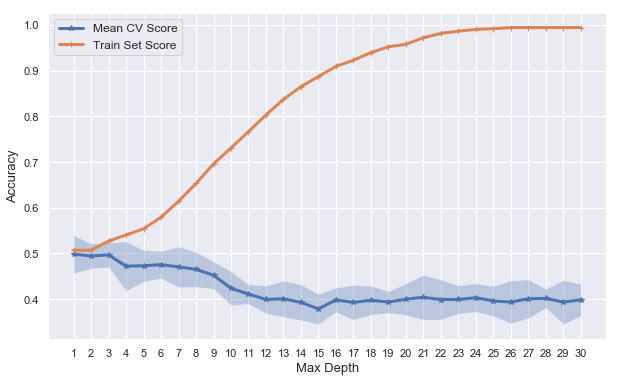

```python
# define the figure and axes
fig, ax = plt.subplots(1,1,figsize=(10,6))

# make the plot
ax.plot(depths, cvmeans, '*-', label="Mean CV Score", lw=3)
ax.fill_between(depths, cvmeans - 2*cvstds, cvmeans + 2*cvstds, alpha=0.3)
ax.plot(depths, train_scores, '-+', label="Train Set Score", lw=3)
ax.legend(fontsize='large')
ax.set_ylabel("Accuracy", fontsize=13)
ax.set_xlabel("Max Depth", fontsize=13)
ax.set_xticks(depths);
```

Training accuracy hits nearly perfect at depth 26 but we don't think that a depth-26 tree will generalize well. `DecisionTreeClassifier` has some randomness in it, so depending on the random choices it made, depth 2, 3 or 4 trees might come out with better validation performance. We'll choose depth 3 here.

```python
# set depth to 3
best_depth = 3

# fit the tree model on train set using depth=3
dtree = DecisionTreeClassifier(criterion='gini', max_depth=best_depth)
dtree.fit(x_train, y_train)
train_score = accuracy_score(y_train, dtree.fit(x_train, y_train).predict(x_train))
test_score = accuracy_score(y_test, dtree.fit(x_train, y_train).predict(x_test))

# print out train and test scores
print('Train Set Accuracy at depth=3: {:.2f}%'.format(train_score * 100))
print('Test Set Accuracy at depth=3: {:.2f}%'.format(test_score * 100))
```

```
Train Set Accuracy at depth=3: 52.70%
Test Set Accuracy at depth=3: 53.65%
```

For the above Decision Tree model, we choose a lower depth so that we don't generate an overfit tree. As a result though, this model underfits the training data. This drawback can be compensated by using Bagging, Random Forests and Boosting models which have less variance. So, we can use higher depths without worrying too much about overfitting on the train set.

##### Bagging

```python
# fit a Bagging model
bagging = BaggingClassifier(base_estimator=DecisionTreeClassifier(max_depth=10), n_estimators=100, oob_score=True)
bagging.fit(x_train, y_train)

# predict
y_pred_train = bagging.predict(x_train)
y_pred_test = bagging.predict(x_test)

# performance evaluation
bag_train_score = accuracy_score(y_train, y_pred_train)
bag_test_score = accuracy_score(y_test, y_pred_test)

print("Training Set Accuracy: {:.2f}%".format(bag_train_score * 100))
print("Testing Set Accuracy: {:.2f}%".format(bag_test_score * 100))
```

```
Training Set Accuracy: 87.86%
Testing Set Accuracy: 47.62%
```

##### Random Forest

```python
# fit a Random Forest model
rforest = RandomForestClassifier(n_estimators=100, max_depth=10)
rforest.fit(x_train, y_train)

# predict
y_pred_train = rforest.predict(x_train)
y_pred_test = rforest.predict(x_test)

# performance evaluation
rf_train_score = accuracy_score(y_train, y_pred_train)
rf_test_score = accuracy_score(y_test, y_pred_test)

print("Training Set Accuracy: {:.2f}%".format(rf_train_score * 100))
print("Testing Set Accuracy: {:.2f}%".format(rf_test_score * 100))
```

```
Training Set Accuracy: 87.62%
Testing Set Accuracy: 49.21%
```

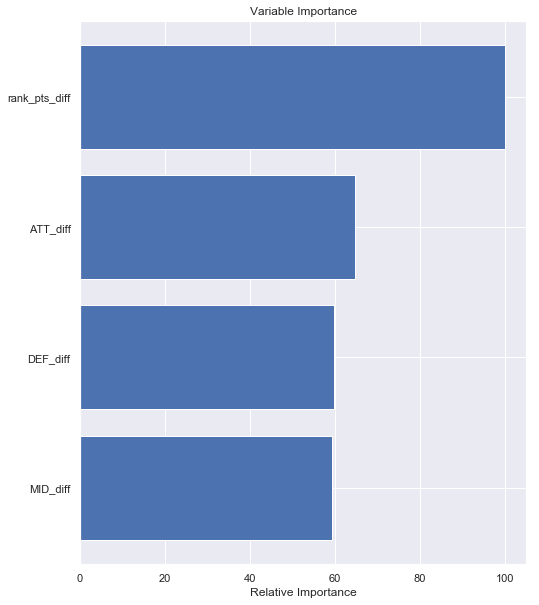

```python
#Top Features
feature_importance = rforest.feature_importances_
feature_importance = 100.0 * (feature_importance / feature_importance.max())
sorted_idx = np.argsort(feature_importance)
pos = np.arange(sorted_idx.shape[0]) + .5

#Plot
plt.figure(figsize=(8,10))
plt.barh(pos, feature_importance[sorted_idx], align='center')
plt.yticks(pos, x_train.columns[sorted_idx])
plt.xlabel('Relative Importance')
plt.title('Variable Importance');
```

Per the random forest model, 'rank_pts_diff' feature is the most important one.

##### Boosting

```
Accuracy, Training Set : 95.15873015873015%
Accuracy, Testing Set : 44.44444444444444%
Best iteration [2] => 0.5333333333333333
```

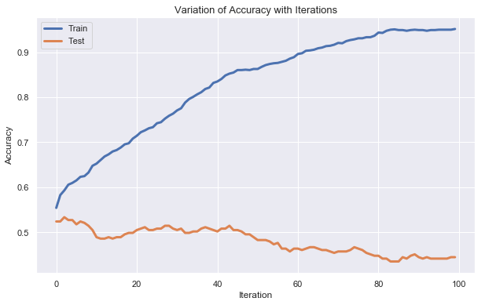

```python
# fit an Adaboost model
adaboost = AdaBoostClassifier(base_estimator=DecisionTreeClassifier(max_depth=5), n_estimators=100, learning_rate=0.05)
adaboost.fit(x_train, y_train)

# predict
y_pred_train = adaboost.predict(x_train)
y_pred_test = adaboost.predict(x_test)

# performance evaluation
train_score = accuracy_score(y_train, y_pred_train)*100
test_score = accuracy_score(y_test, y_pred_test)*100

print("Accuracy, Training Set :",str(train_score)+'%')
print("Accuracy, Testing Set :",str(test_score)+'%')

# plot iteration based score
boost_train_scores = list(adaboost.staged_score(x_train,y_train))
boost_test_scores = list(adaboost.staged_score(x_test, y_test))

fig, ax = plt.subplots(1,1,figsize=(10,6))

ax.plot(boost_train_scores, label='Train', lw=3)
ax.plot(boost_test_scores, label='Test', lw=3)
ax.set_xlabel('Iteration', fontsize=12)
ax.set_ylabel('Accuracy', fontsize=12)
ax.set_title("Variation of Accuracy with Iterations", fontsize=13)
ax.legend();

iteration = np.argmax(boost_test_scores)
print('Best iteration [{}] => {}'.format(iteration, boost_test_scores[iteration]))
```

##### KNN

```python
kvals = list(range(10,200,10))
knn = GridSearchCV(
    KNeighborsClassifier(),
    {'n_neighbors': kvals}).fit(x_train, y_train)

best_k = knn.best_params_['n_neighbors']
print("Best k:", best_k)

best_knn_clf = KNeighborsClassifier(n_neighbors=best_k).fit(x_train, y_train)
print('kNN Train Score:', knn.score(x_train, y_train))
print('kNN Test Score:', knn.score(x_test, y_test))
```

```
Best k: 160
kNN Train Score: 0.5198412698412699
kNN Test Score: 0.5238095238095238
```

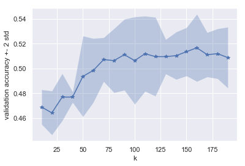

```python
plt.plot(kvals, knn.cv_results_['mean_test_score'], '-*')
plt.fill_between(
    kvals,
    knn.cv_results_['mean_test_score'] - 2 * knn.cv_results_['std_test_score'],
    knn.cv_results_['mean_test_score'] + 2 * knn.cv_results_['std_test_score'],
    alpha=.3)
plt.xlabel('k')
plt.ylabel('validation accuracy +- 2 std');
```

##### SVM

```python
svm_mul = CalibratedClassifierCV(LinearSVC(random_state=0)).fit(x_train, y_train)

# predict
y_pred_train = svm_mul.predict(x_train)
y_pred_test = svm_mul.predict(x_test)

# performance evaluation
svm_train_score = accuracy_score(y_train, y_pred_train)
svm_test_score = accuracy_score(y_test, y_pred_test)

print("Training Set Accuracy: {:.2f}%".format(svm_train_score * 100))
print("Testing Set Accuracy: {:.2f}%".format(svm_test_score * 100))
```

```
Training Set Accuracy: 50.63%
Testing Set Accuracy: 50.79%
```

#### Baseline Model Comparison

Now let's compare all the basic models to see which one performs the best on CV data and test data.

```python
# create a list of all classifiers
named_classifiers = [
    ("Logistic Regression (Multinomial)", logreg_multinomial),
    ("Linear Discriminant Analysis ", lda),
    ("Quadratic Discriminant Analysis", qda),
    (f"Depth-{best_depth} Decision Tree", dtree),
    ("Bagging", bagging),
    ("Depth-10 Random Forest", rforest),
    ("Boosting", adaboost),
    (f"k-NN (k={best_k})", best_knn_clf),
    ("SVM", svm_mul)
]
```

```python
# run cross-validation on all models
cv_scores = [
    cross_val_score(clf, x_train, y_train, cv=5, n_jobs=-1)
    for name, clf in named_classifiers
]
```

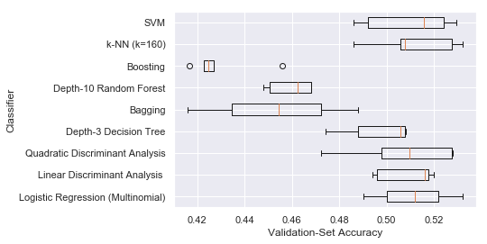

```python
# visualize CV accuracy for each of the models
positions = np.arange(len(named_classifiers))
plt.boxplot(cv_scores, vert=False, positions=positions);
plt.yticks(positions, [name for name, model in named_classifiers])
plt.ylabel("Classifier")
plt.xlabel("Validation-Set Accuracy");
```

```python
# summarize the above results in a table
performance_estimates = pd.DataFrame([
    [scores.mean(), scores.std()] for scores in cv_scores
], index=[name for name, model in named_classifiers], columns=["cv_accuracy", "cv_std"])

performance_estimates.sort_values('cv_accuracy')
```

|  | cv_accuracy | cv_std |
| --- | --- | --- |
| Boosting | 0.429414 | 0.013719 |
| Bagging | 0.453129 | 0.025707 |
| Depth-10 Random Forest | 0.459510 | 0.008644 |
| Depth-3 Decision Tree | 0.496854 | 0.013524 |
| Quadratic Discriminant Analysis | 0.507181 | 0.020837 |
| Linear Discriminant Analysis | 0.508746 | 0.011265 |
| SVM | 0.509549 | 0.017350 |
| Logistic Regression (Multinomial) | 0.511152 | 0.014927 |
| k-NN (k=160) | 0.511962 | 0.016551 |

From the above table, we can see that a kNN model w/ k=160 performs the best on validation set. Now, let's evaluate each fitted model's performance on the test set.

```python
performance_estimates.assign(test_accuracy=[
        accuracy_score(y_test, clf.predict(x_test))
        for name, clf in named_classifiers]).sort_values('cv_accuracy')
```

|  | cv_accuracy | cv_std | test_accuracy |
| --- | --- | --- | --- |
| Boosting | 0.429414 | 0.013719 | 0.444444 |
| Bagging | 0.453129 | 0.025707 | 0.476190 |
| Depth-10 Random Forest | 0.459510 | 0.008644 | 0.492063 |
| Depth-3 Decision Tree | 0.496854 | 0.013524 | 0.536508 |
| Quadratic Discriminant Analysis | 0.507181 | 0.020837 | 0.526984 |
| Linear Discriminant Analysis | 0.508746 | 0.011265 | 0.511111 |
| SVM | 0.509549 | 0.017350 | 0.507937 |
| Logistic Regression (Multinomial) | 0.511152 | 0.014927 | 0.514286 |
| k-NN (k=160) | 0.511962 | 0.016551 | 0.523810 |

For our baseline model, it seems like the kNN model produces the best results on the CV set and also produces one of the top scores on the test set - an accuracy score of 52%. Let's now move on towards building an advanced model with many more features that we developed after scraping the data.

#### Advanced Model

```python
# define the feature set for our model
predictors = ['ATT_diff', 'DEF_diff', 'MID_diff', 'international_prestige_diff', 'DEF_ht_diff',
              'sprint_speed_ATT_diff', 'ball_control_ATT_diff', 'crossing_MID_diff', 'short_passing_MID_diff',
              'finishing_ATT_diff', 'acceleration_ATT_diff', 'strength_DEF_diff']

# scale the features
def scale_df(df, means, stds):
    cols_to_scale = means.index
    df = df.copy()
    df[cols_to_scale] = (df[cols_to_scale] - means) / stds
    return df

cols_to_scale = ['ATT_diff', 'DEF_diff', 'MID_diff', 'international_prestige_diff', 'DEF_ht_diff',
                 'sprint_speed_ATT_diff', 'ball_control_ATT_diff', 'crossing_MID_diff', 'short_passing_MID_diff',
                 'finishing_ATT_diff', 'acceleration_ATT_diff', 'strength_DEF_diff']

train_means = train_data[cols_to_scale].mean(axis=0)
train_stds = train_data[cols_to_scale].std(axis=0)

train_data = scale_df(train_data, train_means, train_stds)
test_data = scale_df(test_data, train_means, train_stds)
wc_data = scale_df(wc_data, train_means, train_stds)

# define x_train, y_train, x_test, y_test and wc x & y
x_train, y_train = train_data[predictors], train_data['outcome_num']
x_test, y_test = test_data[predictors], test_data['outcome_num']
wc_x, wc_y = wc_data[predictors], wc_data['outcome_num']

display(x_train.describe())
display(x_test.describe())
```

|  | ATT_diff | DEF_diff | MID_diff | international_prestige_diff | DEF_ht_diff | sprint_speed_ATT_diff | ball_control_ATT_diff | crossing_MID_diff | short_passing_MID_diff | finishing_ATT_diff | acceleration_ATT_diff | strength_DEF_diff |
| --- | --- | --- | --- | --- | --- | --- | --- | --- | --- | --- | --- | --- |
| count | 1.260000e+03 | 1.260000e+03 | 1.260000e+03 | 1.260000e+03 | 1.260000e+03 | 1.260000e+03 | 1.260000e+03 | 1.260000e+03 | 1.260000e+03 | 1.260000e+03 | 1.260000e+03 | 1.260000e+03 |
| mean | -5.282371e-17 | -2.713879e-17 | 2.787012e-16 | -3.044302e-17 | -1.818651e-16 | -6.924796e-16 | 3.158012e-15 | -6.396999e-17 | -3.110387e-17 | 3.913977e-16 | 2.644578e-15 | -5.692096e-17 |
| std | 1.000000e+00 | 1.000000e+00 | 1.000000e+00 | 1.000000e+00 | 1.000000e+00 | 1.000000e+00 | 1.000000e+00 | 1.000000e+00 | 1.000000e+00 | 1.000000e+00 | 1.000000e+00 | 1.000000e+00 |
| min | -2.723790e+00 | -2.877528e+00 | -3.999943e+00 | -3.243854e+00 | -2.825025e+00 | -5.215673e+00 | -2.997782e+00 | -4.333476e+00 | -3.287798e+00 | -3.370251e+00 | -3.900517e+00 | -3.069593e+00 |
| 25% | -6.851080e-01 | -6.801429e-01 | -6.924103e-01 | -6.110549e-01 | -7.169618e-01 | -5.909698e-01 | -6.682951e-01 | -6.971111e-01 | -7.084617e-01 | -6.788980e-01 | -6.430467e-01 | -6.954343e-01 |
| 50% | 4.299261e-02 | 5.231869e-02 | 5.930173e-02 | 4.714486e-02 | -2.030588e-02 | 8.385292e-02 | -3.201652e-02 | 4.753698e-02 | 4.103115e-02 | 1.286589e-02 | 1.105397e-02 | 6.261502e-03 |
| 75% | 7.710932e-01 | 7.847803e-01 | 6.606714e-01 | 5.407947e-01 | 6.673026e-01 | 6.534281e-01 | 6.705411e-01 | 6.887617e-01 | 7.196261e-01 | 6.863568e-01 | 6.741149e-01 | 6.789398e-01 |
| max | 3.101015e+00 | 2.689181e+00 | 4.569574e+00 | 3.009044e+00 | 3.562496e+00 | 3.211210e+00 | 3.082214e+00 | 3.410864e+00 | 3.858268e+00 | 2.873897e+00 | 2.863682e+00 | 3.841847e+00 |

|  | ATT_diff | DEF_diff | MID_diff | international_prestige_diff | DEF_ht_diff | sprint_speed_ATT_diff | ball_control_ATT_diff | crossing_MID_diff | short_passing_MID_diff | finishing_ATT_diff | acceleration_ATT_diff | strength_DEF_diff |
| --- | --- | --- | --- | --- | --- | --- | --- | --- | --- | --- | --- | --- |
| count | 315.000000 | 315.000000 | 315.000000 | 315.000000 | 315.000000 | 315.000000 | 315.000000 | 315.000000 | 315.000000 | 315.000000 | 315.000000 | 315.000000 |
| mean | 0.010633 | 0.015579 | 0.013960 | 0.009533 | 0.076696 | -0.007901 | -0.027840 | 0.137258 | 0.002030 | 0.003744 | -0.027748 | 0.042370 |
| std | 1.018096 | 0.971903 | 1.019967 | 0.946067 | 1.037212 | 0.954078 | 1.047389 | 1.025792 | 1.006055 | 1.034742 | 0.928356 | 1.118254 |
| min | -2.578170 | -2.731035 | -3.398574 | -2.585654 | -2.372651 | -3.347749 | -3.531549 | -2.689045 | -2.941185 | -2.701981 | -3.186952 | -3.254250 |
| 25% | -0.685108 | -0.533651 | -0.692410 | -0.446505 | -0.563155 | -0.549401 | -0.753132 | -0.551284 | -0.711838 | -0.686356 | -0.590100 | -0.684882 |
| 50% | -0.102628 | 0.052319 | 0.059302 | -0.117405 | 0.015884 | 0.080315 | -0.095644 | 0.140618 | -0.060252 | -0.035862 | 0.009425 | 0.095952 |
| 75% | 0.771093 | 0.638288 | 0.660671 | 0.623070 | 0.766825 | 0.628159 | 0.607797 | 0.828383 | 0.788273 | 0.716812 | 0.635015 | 0.781820 |
| max | 2.664155 | 2.542688 | 2.915808 | 2.515394 | 2.802508 | 2.227720 | 2.831237 | 4.713998 | 2.417801 | 3.557830 | 2.365165 | 3.367015 |

##### Logistic Regression

```python
# fit logistic (multinomial) regression
logreg_multinomial = LogisticRegressionCV(multi_class = 'multinomial', solver='saga', cv=5, penalty='l2')
logreg_multinomial.fit(x_train, y_train)
print('Logistic Regression Train Score: ',logreg_multinomial.score(x_train, y_train))
print('Logistic Regression CV Score: ',cross_val_score(logreg_multinomial, x_train, y_train, cv=5).mean())
```

```
Logistic Regression Train Score:  0.5134920634920634
Logistic Regression CV Score:  0.5127114875462702
```

##### LDA & QDA

```python
# fit lda and qda
lda = LinearDiscriminantAnalysis()
qda = QuadraticDiscriminantAnalysis()
lda.fit(x_train, y_train)
qda.fit(x_train, y_train)

print('LDA Train Score: ',lda.score(x_train, y_train))
print('LDA CV Score: ',cross_val_score(lda, x_train, y_train, cv=5).mean())
print('\n')
print('QDA Train Score: ',qda.score(x_train, y_train))
print('QDA CV Score: ',cross_val_score(qda, x_train, y_train, cv=5).mean())
```

```
LDA Train Score:  0.5134920634920634
LDA CV Score:  0.49293303218520607


QDA Train Score:  0.546031746031746
QDA CV Score:  0.4603675010979359
```

##### Decision Tree

```python
# define the list of depths we want to test
depths = list(range(1, 31))
train_scores = []
cvmeans = []
cvstds = []

for depth in depths:
    dtree = DecisionTreeClassifier(criterion='gini', max_depth=depth)
    dtree.fit(x_train, y_train)

    # Perform 5-fold cross validation and store results
    train_scores.append(dtree.score(x_train, y_train))
    scores = cross_val_score(estimator=dtree, X=x_train, y=y_train, cv=5)
    cvmeans.append(scores.mean())
    cvstds.append(scores.std())

cvmeans = np.array(cvmeans)
cvstds = np.array(cvstds)
```

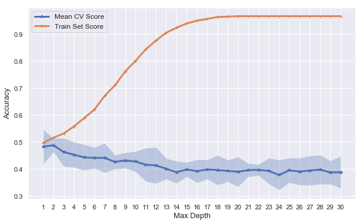

```python
# define the figure and axes
fig, ax = plt.subplots(1,1,figsize=(10,6))

# make the plot
ax.plot(depths, cvmeans, '*-', label="Mean CV Score", lw=3)
ax.fill_between(depths, cvmeans - 2*cvstds, cvmeans + 2*cvstds, alpha=0.3)
ax.plot(depths, train_scores, '-+', label="Train Set Score", lw=3)
ax.legend(fontsize='large')
ax.set_ylabel("Accuracy", fontsize=13)
ax.set_xlabel("Max Depth", fontsize=13)
ax.set_xticks(depths);
```

Training accuracy hits nearly perfect at depth 20 but we don't think that a depth-20 tree will generalize well. DecisionTreeClassifier has some randomness in it, so depending on the random choices it made, depth 2 or depth 3 trees might come out with better validation performance. We'll choose depth 3 here.

```python
# set depth to 3
best_depth = 3

# fit the tree model on test set using depth=3
dtree = DecisionTreeClassifier(criterion='gini', max_depth=best_depth)
dtree.fit(x_train, y_train)
train_score = accuracy_score(y_train, dtree.fit(x_train, y_train).predict(x_train))
test_score = accuracy_score(y_test, dtree.fit(x_train, y_train).predict(x_test))

# print out train and test scores
print('Accuracy on Train Set at depth=3: {:.2f}%'.format(train_score * 100))
print('Accuracy on Test Set at depth=3: {:.2f}%'.format(test_score * 100))
```

```
Accuracy on Train Set at depth=3: 53.17%
Accuracy on Test Set at depth=3: 50.48%
```

##### Bagging

```python
# fit a Bagging model
bagging = BaggingClassifier(base_estimator=DecisionTreeClassifier(max_depth=10), n_estimators=100, oob_score=True)
bagging.fit(x_train, y_train)

# predict
y_pred_train = bagging.predict(x_train)
y_pred_test = bagging.predict(x_test)

# performance evaluation
bag_train_score = accuracy_score(y_train, y_pred_train)
bag_test_score = accuracy_score(y_test, y_pred_test)

print("Training Set Accuracy: {:.2f}%".format(bag_train_score * 100))
print("Testing Set Accuracy: {:.2f}%".format(bag_test_score * 100))
```

```
Training Set Accuracy: 93.89%
Testing Set Accuracy: 50.48%
```

##### Random Forest

```python
# fit a Random Forest model
rforest = RandomForestClassifier(n_estimators=100, max_depth=10)
rforest.fit(x_train, y_train)

# predict
y_pred_train = rforest.predict(x_train)
y_pred_test = rforest.predict(x_test)

# performance evaluation
rf_train_score = accuracy_score(y_train, y_pred_train)
rf_test_score = accuracy_score(y_test, y_pred_test)

print("Training Set Accuracy: {:.2f}%".format(rf_train_score * 100))
print("Testing Set Accuracy: {:.2f}%".format(rf_test_score * 100))
```

```
Training Set Accuracy: 91.98%
Testing Set Accuracy: 52.06%
```

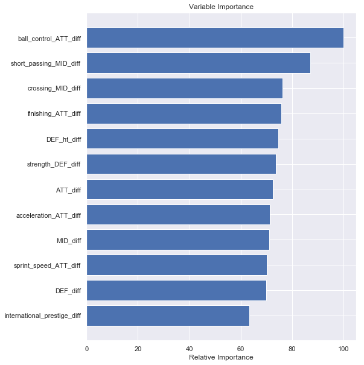

```python
# top features
feature_importance = rforest.feature_importances_
feature_importance = 100.0 * (feature_importance / feature_importance.max())
sorted_idx = np.argsort(feature_importance)
pos = np.arange(sorted_idx.shape[0]) + .5

# make the plot
plt.figure(figsize=(8,10))
plt.barh(pos, feature_importance[sorted_idx], align='center')
plt.yticks(pos, x_train.columns[sorted_idx])
plt.xlabel('Relative Importance')
plt.title('Variable Importance');
```

Per this random forest model, 'ball_control_ATT_diff' is the most important feature in our dataset, whereas the 'international_prestige_diff' seems to be the least important.

##### Boosting

```
Training Set Accuracy : 93.96825396825396%
Testing Set Accuracy : 49.2063492063492%
Best iteration [88] => 0.5111111111111111
```

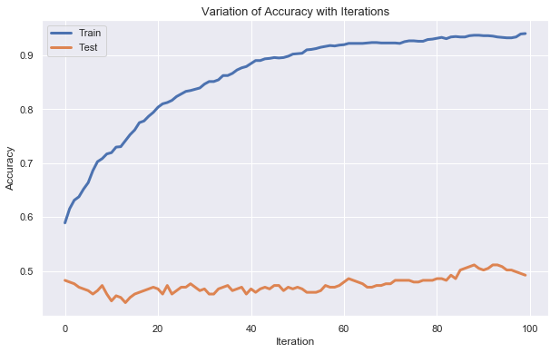

```python
# fit an Adaboost model
adaboost = AdaBoostClassifier(base_estimator=DecisionTreeClassifier(max_depth=5), n_estimators=100, learning_rate=0.05)
adaboost.fit(x_train, y_train)

# predict
y_pred_train = adaboost.predict(x_train)
y_pred_test = adaboost.predict(x_test)

# performance evaluation
train_score = accuracy_score(y_train, y_pred_train)*100
test_score = accuracy_score(y_test, y_pred_test)*100

print("Training Set Accuracy :",str(train_score)+'%')
print("Testing Set Accuracy :",str(test_score)+'%')

# plot iteration based score
boost_train_scores = list(adaboost.staged_score(x_train,y_train))
boost_test_scores = list(adaboost.staged_score(x_test, y_test))

fig, ax = plt.subplots(1,1,figsize=(10,6))

ax.plot(boost_train_scores, label='Train', lw=3)
ax.plot(boost_test_scores, label='Test', lw=3)
ax.set_xlabel('Iteration', fontsize=12)
ax.set_ylabel('Accuracy', fontsize=12)
ax.set_title("Variation of Accuracy with Iterations", fontsize=13)
ax.legend();

iteration = np.argmax(boost_test_scores)
print('Best iteration [{}] => {}'.format(iteration, boost_test_scores[iteration]))
```

##### KNN

```python
kvals = list(range(10,200,10))
knn = GridSearchCV(
    KNeighborsClassifier(),
    {'n_neighbors': kvals}).fit(x_train, y_train)

best_k = knn.best_params_['n_neighbors']
print("Best k:", best_k)

best_knn_clf = KNeighborsClassifier(n_neighbors=best_k).fit(x_train, y_train)
print('kNN Train Score:', knn.score(x_train, y_train))
print('kNN Test Score:', knn.score(x_test, y_test))
```

```
Best k: 130
kNN Train Score: 0.5119047619047619
kNN Test Score: 0.526984126984127
```

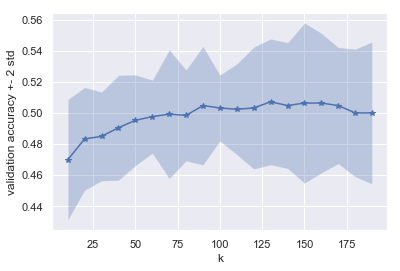

```python
plt.plot(kvals, knn.cv_results_['mean_test_score'], '-*')
plt.fill_between(
    kvals,
    knn.cv_results_['mean_test_score'] - 2 * knn.cv_results_['std_test_score'],
    knn.cv_results_['mean_test_score'] + 2 * knn.cv_results_['std_test_score'],
    alpha=.3)
plt.xlabel('k')
plt.ylabel('validation accuracy +- 2 std');
```

#### SVM

```python
svm_mul = CalibratedClassifierCV(LinearSVC(random_state=0)).fit(x_train, y_train)

# predict
y_pred_train = svm_mul.predict(x_train)
y_pred_test = svm_mul.predict(x_test)

# performance evaluation
svm_train_score = accuracy_score(y_train, y_pred_train)
svm_test_score = accuracy_score(y_test, y_pred_test)

print("Training Set Accuracy: {:.2f}%".format(svm_train_score * 100))
print("Testing Set Accuracy: {:.2f}%".format(svm_test_score * 100))
```

```
Training Set Accuracy: 52.06%
Testing Set Accuracy: 52.06%
```

#### Advanced Models Comparison

```python
# create a list of all classifiers
named_classifiers = [
    ("Logistic Regression (Multinomial)", logreg_multinomial),
    ("Linear Discriminant Analysis ", lda),
    ("Quadratic Discriminant Analysis", qda),
    (f"Depth-{best_depth} Decision Tree", dtree),
    ("Bagging", bagging),
    ("Depth-10 Random Forest", rforest),
    ("Boosting", adaboost),
    (f"k-NN (k={best_k})", best_knn_clf),
    ("SVM", svm_mul)
]
```

```python
# run cross-validation on all models
cv_scores = [
    cross_val_score(clf, x_train, y_train, cv=5, n_jobs=-1)
    for name, clf in named_classifiers
]
```

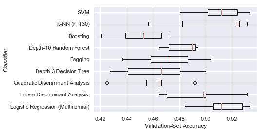

```python
# visualize CV accuracy for each of the models
positions = np.arange(len(named_classifiers))
plt.boxplot(cv_scores, vert=False, positions=positions);
plt.yticks(positions, [name for name, model in named_classifiers])
plt.ylabel("Classifier")
plt.xlabel("Validation-Set Accuracy");
```

```python
# summarize the above results in a table
performance_estimates = pd.DataFrame([
    [scores.mean(), scores.std()] for scores in cv_scores
], index=[name for name, model in named_classifiers], columns=["cv_accuracy", "cv_std"])

performance_estimates.sort_values('cv_accuracy')
```

|  | cv_accuracy | cv_std |
| --- | --- | --- |
| Boosting | 0.450031 | 0.018697 |
| Quadratic Discriminant Analysis | 0.460368 | 0.021750 |
| Depth-3 Decision Tree | 0.462783 | 0.026408 |
| Bagging | 0.471479 | 0.023088 |
| Depth-10 Random Forest | 0.482508 | 0.012045 |
| Linear Discriminant Analysis | 0.492933 | 0.024218 |
| k-NN (k=130) | 0.504013 | 0.029638 |
| SVM | 0.510327 | 0.018497 |
| Logistic Regression (Multinomial) | 0.512711 | 0.017514 |

From the above table, we can see that Logistic Regression model performs best on the validation set. Now, let's evaluate each fitted model's performance on the test set.

```python
performance_estimates.assign(test_accuracy=[
        accuracy_score(y_test, clf.predict(x_test))
        for name, clf in named_classifiers]).sort_values('cv_accuracy')
```

|  | cv_accuracy | cv_std | test_accuracy |
| --- | --- | --- | --- |
| Boosting | 0.450031 | 0.018697 | 0.492063 |
| Quadratic Discriminant Analysis | 0.460368 | 0.021750 | 0.438095 |
| Depth-3 Decision Tree | 0.462783 | 0.026408 | 0.504762 |
| Bagging | 0.471479 | 0.023088 | 0.504762 |
| Depth-10 Random Forest | 0.482508 | 0.012045 | 0.520635 |
| Linear Discriminant Analysis | 0.492933 | 0.024218 | 0.501587 |
| k-NN (k=130) | 0.504013 | 0.029638 | 0.526984 |
| SVM | 0.510327 | 0.018497 | 0.520635 |
| Logistic Regression (Multinomial) | 0.512711 | 0.017514 | 0.526984 |

For our advanced model, the Logistic Regression model produces the best results on the CV set and also generalizes well on the test set. It produces a test accuracy of 53%. So, it seems like adding these new features in the advanced model has marginally improved our accuracy on the test set.

But let's now use this logistic model on our reserved World Cup data to predict match outcomes.

```python
wc_accuracy = accuracy_score(wc_y, logreg_multinomial.predict(wc_x))
wc_accuracy
```

```
0.609375
```

```python
# confusion matrix for the logistic regression model
pd.crosstab(np.array(wc_y), logreg_multinomial.predict(wc_x), margins=True, rownames=['Actual'], colnames=['Predicted'])
```

| Predicted Actual | 0.0 | 2.0 | All |
| --- | --- | --- | --- |
| 0.0 | 24 | 2 | 26 |
| 1.0 | 10 | 3 | 13 |
| 2.0 | 10 | 15 | 25 |
| All | 44 | 20 | 64 |

From the above confusion matrix, we can see that though our best advanced model fails to predict any draws, it does produce an accuracy of 61%.